# Advanced Clustering Techniques

## Gaussian Mixture Models and Expectation-Maximization

### What you will Learn in this Chapter

Upon completing this lesson, students will be able to:

1. **Understand Gaussian Mixture Models (GMMs):**
   - Describe what Gaussian Mixture Models are and how they differ from other clustering algorithms like K-Means.
   - Explain the concept of mixture modeling and how GMMs utilize probability distributions to perform soft clustering.
2. **Apply GMMs to Synthetic Data:**
   - Generate synthetic datasets with specified characteristics using scikit-learn's `make_blobs` or similar functions.
   - Understand the importance of parameters such as the number of components and covariance type in GMMs and how they affect the model's behavior and performance.
3. **Fit a GMM Using scikit-learn:**
   - Use the `GaussianMixture` class from scikit-learn's `mixture` module to fit a GMM to data.
   - Interpret the key attributes of a fitted GMM, including the means, covariances, and weights of the components.

### Introduction

- Gaussian Mixture Models (GMMs) are a type of unsupervised learning model that assumes all the data points are generated from a mixture of several Gaussian distributions with unknown parameters, each representing one cluster or component.
- These Gaussian distributions are blended together to form the complete dataset.
- GMMs are used for clustering similar to k-means but provide more flexibility due to the incorporation of distributional information.
- GMMs can accommodate clusters that have different sizes and correlations as well as different shapes, unlike k-means which assumes all clusters are spherical.

[figure not shown]

Here, we can see that there are three Gaussian functions, hence K = 3. Each Gaussian explains the data contained in each of the three clusters available. The mixing coefficients are themselves probabilities and must meet this condition:

$$\sum\limits_{k=1}^K \pi_k = 1$$

- All the instances generated from a single Gaussian distribution form a cluster that typically looks like an ellipsoid.
- Each cluster can have a different ellipsoidal shape, size, density and orientation

[figure not shown]

**How GMMs Work**

1. **Mixture of Gaussians**: A GMM models the data as a finite mixture of Gaussian distributions. Each Gaussian, also known as a component of the mixture, has its own mean (center) and covariance (shape, orientation, and size). The mixture model allows for the representation of an overall distribution that can capture more complexity than a single Gaussian distribution.
2. **Expectation-Maximization (EM) Algorithm**: To estimate the parameters (means, covariances, and mixture weights) of the Gaussian components, GMMs typically use the Expectation-Maximization (EM) algorithm. The EM algorithm iteratively performs two steps until convergence:
   - **Expectation Step (E-step)**: Given the current parameters, compute the probability that each data point belongs to each Gaussian component. This step essentially assigns weights to each data point based on how likely they are to belong to each component.
   - **Maximization Step (M-step)**: Update the parameters of the Gaussians to maximize the likelihood of the data given these new assignments.

**Soft Clustering**

- Unlike k-means which assigns each data point to exactly one cluster, GMMs allow for soft clustering.
- This means each data point is assigned a probability (or weight) reflecting how likely it is to belong to each cluster.
- This probabilistic approach enables the model to express uncertainty about the assignments, especially when data points are equidistant to cluster centers or when clusters overlap.

### The Algorithm

- As we have said, The Gaussian Mixture Model (GMM) enhances the K-Means approach by utilizing Gaussian distributions to characterize clusters.
- Distinct from K-Means, GMM captures not just the cluster centers but also their covariances, facilitating the depiction of the clusters' ellipsoidal contours.
- The fitting of GMM employs the Expectation Maximization (EM) algorithm, aimed at optimizing the likelihood of the given data.
- Unlike the hard clustering of K-Means, EM allocates data points to clusters based on soft probabilities, offering a more nuanced assignment process.
- The first step, known as the **expectation step** or **𝐸 step**, consists of calculating the expectation of the component assignments $𝐶_𝑘$ for each data point $𝑥_𝑖\in𝑋$ given the model parameters $\pi_k$, $\mu_k$ and $\sigma_k$ (the probability of each data point belonging to each distribution).
- For each point $x_i$ compute $r_{ic}$ the probability that $x_i$ belong to the cluster $c$

$$r_{ic} = \frac{\pi_c \, \cal N \left(x_i; \mu_c, \Sigma_c \right)} {\sum\limits_{c^\prime} \pi_{c^\prime} \, \cal N \left( x_i; \mu_{c^\prime},\Sigma_{c^\prime} \right)}$$

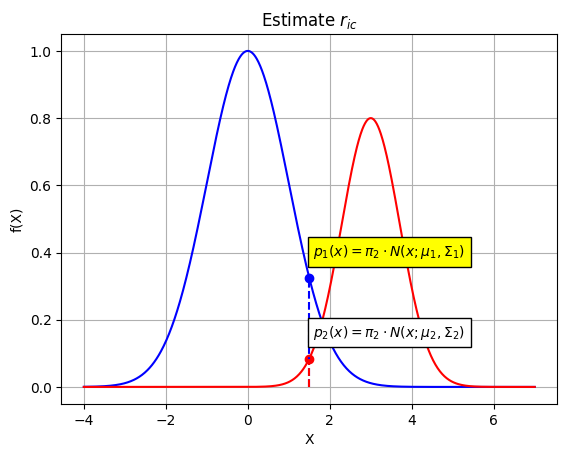

- The second step is known as the **maximization step** or **𝑀 step**, which consists of maximizing the expectations calculated in the previous step with respect to the model parameters. This step consists of updating the values $\pi_k$, $\mu_k$ and $\sigma_k$.
- For each cluster $c$, update its parameters using the weighted data points:

$$m_c = \sum\limits_i r_{ic} \quad \text{Total Responsability Allocated to Cluster $c$}$$

$$\pi_c = \frac{m_c}{m} \quad \text{Fraction of Total Assigned to Cluster $c$}$$

$$\mu_c = \frac{1}{m_c}\sum\limits_i r_{ic}\, x_i, \quad \Sigma_c = \frac{1}{m_c}\sum\limits_i r_{ic}\, (x_i - \mu_c)^T (x_i - \mu_c)$$

- The entire iterative process repeats until the algorithm converges, giving a maximum likelihood estimate. Intuitively, the algorithm works because knowing the component assignment $𝐶_𝑘$ for each $𝑥_𝑖$ makes solving for $\pi_k$, $\mu_k$ and $\sigma_k$ easy while knowing $\pi_k$, $\mu_k$ and $\sigma_k$ makes inferring $𝑝(𝐶_𝑘\vert𝑥_𝑖)$ easy.

**Algorithm**

**1** Initialize the mean $(\mu_𝑘)$, covariance matrix $(\sigma_𝑘)$, and mixing coefficients $(\pi_𝑘)$ with random or predefined values. Usually for the weights we use an equal probability a priori that means that, in the beginning, weights will be equal for all clusters. Assume that we fit a GMM with three components. In this case weight parameter might be set to 1/3 for each component, resulting in a probability distribution of (1/3, 1/3, 1/3).

**2** For each data point $x_i$, calculate the probability that the data point belongs to cluster $k$ (component assignments $(𝐶_𝑘(x_i))$) for all clusters.

**3** Estimate all the parameters using the current component assignments $(𝐶_𝑘)$.

**4** Compute the log-likelihood function.

**5** Set a convergence criterion.

**6** If the log-likelihood value converges to a specific threshold or if all the parameters converge to certain values, stop the algorithm. Otherwise, go back to Step 2.

[figure not shown]

*Source: Ravihara R. See the References and Credits Section*

**Advantages of GMMs**

- **Flexibility in Cluster Shapes**: GMMs can capture elongated or elliptical clusters due to the model's ability to fit Gaussians with different covariances.
- **Handling Overlapping Clusters**: GMM can effectively handle situations where clusters overlap. Unlike algorithms like K-Means, which assume non-overlapping clusters, GMM can represent the uncertainty when points are near the boundary between clusters.
- **Soft Clustering**: The probabilistic cluster assignments can be more informative, especially in cases where data points could plausibly belong to multiple clusters.
- **Density Estimation**: Beyond clustering, GMMs provide a way to estimate the density distribution of the data, which can be useful for anomaly detection or generating new data points that are similar to the input data.
- **Robustness to Outliers**: GMM is less sensitive to outliers compared to some other clustering methods like K-Means. Outliers are less likely to dominate the cluster assignment.

**Use Cases**

- **Clustering**: Identifying natural groupings in data when clusters may have different sizes, shapes, and densities.
- **Anomaly Detection**: Spotting outliers by evaluating how well they fit into the learned mixture of Gaussians.
- **Image Segmentation**: Grouping pixels in images into coherent regions or objects based on color or texture.

**Considerations**

- **Initialization Sensitivity**: The results of GMMs can be sensitive to the initialization of parameters. Multiple runs with different initializations may be necessary to find a good solution.
- **Computational Complexity**: The EM algorithm can be computationally intensive, especially as the number of components and dimensions of the data increase.
- **Model Selection**: Determining the optimal number of Gaussian components in the mixture is a non-trivial problem and often requires criteria like [Bayesian Information Criterion (BIC)](https://en.wikipedia.org/wiki/Bayesian_information_criterion) or [Akaike Information Criterion (AIC)](https://en.wikipedia.org/wiki/Akaike_information_criterion) for model selection.

### Selecting the Number of Clusters

Determining the number of clusters in a Gaussian Mixture Model (GMM) for clustering involves finding the model that best balances fit and complexity. GMMs assume that the data is generated from a mixture of several Gaussian distributions, with each distribution representing a cluster. The challenge is to select the right number of Gaussian components (clusters) that best represent the underlying data without overfitting. Several methods are commonly used to make this decision:

**Akaike Information Criterion (AIC)**

The AIC is a metric that quantifies the goodness of fit of a model and the complexity of the model. It penalizes the likelihood of the model by the number of parameters used. The goal is to minimize the AIC value. When comparing multiple GMMs with different numbers of clusters, the model with the lowest AIC value is generally preferred.

**Bayesian Information Criterion (BIC)**

Similar to AIC, the BIC also includes a penalty term for the number of parameters in the model. However, BIC tends to impose a heavier penalty than AIC, leading to the selection of simpler models with fewer clusters. As with AIC, the model with the lowest BIC value is preferred.

**Cross-Validation**

Cross-validation, particularly a method known as "log-likelihood cross-validation," can be used. The idea is to divide the data into training and validation sets, fit the model on the training set, and then evaluate its performance on the validation set based on the log-likelihood. The model that performs best on the validation set (often with the highest log-likelihood) indicates an appropriate number of clusters. However, cross-validation can be computationally expensive for GMMs.

**Silhouette Score**

The silhouette score is a measure of how similar an object is to its own cluster compared to other clusters. The silhouette scores range from -1 to 1, where a high value indicates that the object is well matched to its own cluster and poorly matched to neighboring clusters. By calculating the average silhouette score for different numbers of clusters, you can select the number that maximizes the score.

**Elbow Method**

Although more heuristic and visual, the elbow method involves plotting a relevant metric (like the total within-cluster variance, AIC, or BIC) against the number of clusters and looking for an "elbow" point. This point represents where the rate of decrease sharply changes, suggesting diminishing returns by increasing the number of clusters.

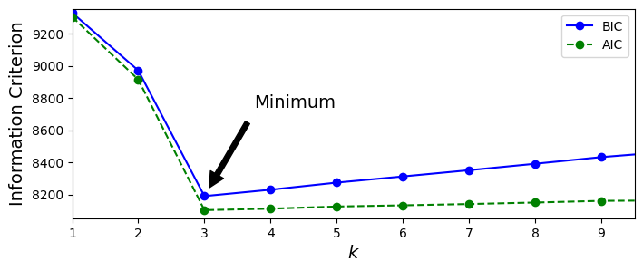

**Choosing the Right Method**

The choice of method depends on the specific dataset and the goals of the clustering. AIC and BIC are widely used due to their balance of model complexity and fit, and they offer a straightforward criterion for model selection. Cross-validation and silhouette scores can provide additional insights but might require more computational resources or might not be as straightforward to interpret.

In practice, it's often recommended to use a combination of these methods rather than relying on a single criterion, and to consider the domain knowledge and the specific context of the data when deciding on the number of clusters.

## Cluster Validation Techniques

### Introduction

- Cluster validation techniques are crucial for assessing the quality of clustering results.
- These techniques help in determining the effectiveness of the clustering process, including how well the data points have been grouped into clusters.
- Cluster validation can be broadly categorized into three types: **internal, external, and relative validation methods**.
- Each type offers a different approach to validate the clustering results, and they can be used based on the availability of ground truth data and the specific goals of the clustering analysis.

### Internal Validation Methods

Internal validation methods evaluate the clustering quality using the dataset itself without any reference to external data. These methods often focus on the compactness and separation of the clusters:

- **Silhouette Coefficient**: We have already discussed this method in the previous chapters. As we known, it measures how similar an object is to its own cluster compared to other clusters. The value ranges from -1 (incorrect clustering) to +1 (highly dense clustering), with 0 indicating overlapping clusters.
- **Davies-Bouldin Index**: Evaluates the clustering quality by measuring the ratio between within-cluster distances and between-cluster distances. **Lower values indicate better clustering**.
- **Calinski-Harabasz Index**: Also known as the Variance Ratio Criterion, it measures the ratio of the sum of between-clusters dispersion to within-cluster dispersion. **Higher values typically indicate better-defined clusters**.

### External Validation Methods

External validation methods require ground truth labels to assess the clustering performance. These methods compare the clustering results against a predefined set of labels:

- **Adjusted Rand Index (ARI)**: Measures the similarity between two clusterings, taking into account the chance grouping of elements. It has a maximum value of 1 (perfect match) and can have negative values for independent clusterings.
- **Normalized Mutual Information (NMI)**: Measures the mutual information between the ground truth and the clustering results, normalized to account for the size of the clusters. A value of 1 indicates perfect agreement, while 0 indicates no mutual information.
- **Homogeneity, Completeness, and V-Measure**: These metrics assess the quality of clustering from different perspectives. Homogeneity checks if each cluster contains only members of a single class. Completeness assesses whether all members of a given class are assigned to the same cluster. V-Measure is the harmonic mean of homogeneity and completeness.

### Relative Validation Methods

Relative validation methods involve comparing different clustering models or configurations to determine which one performs best for a particular dataset:

- **Gap Statistic**: Compares the total within intra-cluster variation for different values of k (number of clusters) with their expected values under null reference distribution of the data. The optimal number of clusters is the value of k that maximizes the gap statistic.
- **Elbow Method**: Involves plotting the explained variation as a function of the number of clusters and picking the elbow of the curve as the number of clusters to use.

Choosing the appropriate cluster validation technique depends on the specific objectives of the clustering analysis, whether external labels are available, and the characteristics of the dataset being analyzed. Combining multiple validation measures can provide a more comprehensive assessment of the clustering quality.

## References and Credits

[1] - Géron A. - "Hands On Machine Learning with Scikit-Learn Keras and Tensorflow", O Reilly

[2] - Yenigün O. - "Clustering With Gaussian Mixture Models", Published in [Towards Dev](https://towardsdev.com/clustering-with-gaussian-mixture-models-c2c3ecdc6640) May 15, 2023

[3] - Yehoshua R. - "Gaussian Mixture Models (GMMs): from Theory to Implementation", Published in [Towards Data Science](https://towardsdatascience.com/gaussian-mixture-models-gmms-from-theory-to-implementation-4406c7fe9847) Nov 28, 2023

[4] - Contreras Carrasco O. - "Gaussian Mixture Models Explained: From intuition to implementation", Published in [Towards Data Science](https://towardsdatascience.com/gaussian-mixture-models-explained-6986aaf5a95) Jun 3, 2019

[5] - Atta S. - "Gaussian Mixture Models (GMM) Clustering in Python", Published in [Medium](https://soumenatta.medium.com/gaussian-mixture-models-gmm-clustering-in-python-d8d6ca2693f2) Apr 10, 2023

[6] - Gandhi V. - "Gaussian Mixture Models Clustering - Explained", Published in [Kaggle](https://www.kaggle.com/code/vipulgandhi/gaussian-mixture-models-clustering-explained)

[7] - Ravihara R. - ["Gaussian Mixture Model Clearly Explained"](https://towardsdatascience.com/gaussian-mixture-model-clearly-explained-115010f7d4cf), Published in Towards Data Science an 10, 2023